# Cox Proportional Hazards Practice

#### General Examination of Data

```r
#libraries
library(tidyverse)
library(survival)
library(survminer)
library(ggpubr)
library(magrittr)
library(ggfortify)
```

Dataset is from the Mayo Clinic Primary Biliary Cirrhosis data on Kaggle: https://www.kaggle.com/datasets/jixing475/mayo-clinic-primary-biliary-cirrhosis-data

```r
pbc <- read.csv('C:/Users/jayre/Desktop/Capstone/pbc.csv')

head(pbc, n = 5)
```

```
  id time status trt      age sex ascites hepato spiders edema bili chol
1  1  400      2   1 58.76523   f       1      1       1   1.0 14.5  261
2  2 4500      0   1 56.44627   f       0      1       1   0.0  1.1  302
3  3 1012      2   1 70.07255   m       0      0       0   0.5  1.4  176
4  4 1925      2   1 54.74059   f       0      1       1   0.5  1.8  244
5  5 1504      1   2 38.10541   f       0      1       1   0.0  3.4  279
  albumin copper alk.phos    ast trig platelet protime stage
1    2.60    156   1718.0 137.95  172      190    12.2     4
2    4.14     54   7394.8 113.52   88      221    10.6     3
3    3.48    210    516.0  96.10   55      151    12.0     4
4    2.54     64   6121.8  60.63   92      183    10.3     4
5    3.53    143    671.0 113.15   72      136    10.9     3
```

```r
#sex needs to be 0,1, need no na's in the treatment column, and don't want the transplant category in status
pbc <- pbc %>%
        mutate(sex = if_else(sex == "f", 1, 0)) %>%
        na.omit(trt) %>%
        filter(status != 1)

#switch status to be 1 (alive) or 2 (deceased)
pbc <- pbc %>% mutate(status = if_else(status == 0, 1, 2))

head(pbc, n = 5)
```

```
  id time status trt      age sex ascites hepato spiders edema bili chol
1  1  400      2   1 58.76523   1       1      1       1   1.0 14.5  261
2  2 4500      1   1 56.44627   1       0      1       1   0.0  1.1  302
3  3 1012      2   1 70.07255   0       0      0       0   0.5  1.4  176
4  4 1925      2   1 54.74059   1       0      1       1   0.5  1.8  244
5  7 1832      1   2 55.53457   1       0      1       0   0.0  1.0  322
  albumin copper alk.phos    ast trig platelet protime stage
1    2.60    156   1718.0 137.95  172      190    12.2     4
2    4.14     54   7394.8 113.52   88      221    10.6     3
3    3.48    210    516.0  96.10   55      151    12.0     4
4    2.54     64   6121.8  60.63   92      183    10.3     4
5    4.09     52    824.0  60.45  213      204     9.7     3
```

#### Kaplan-Meier Survival Curves and Log-Rate Tests

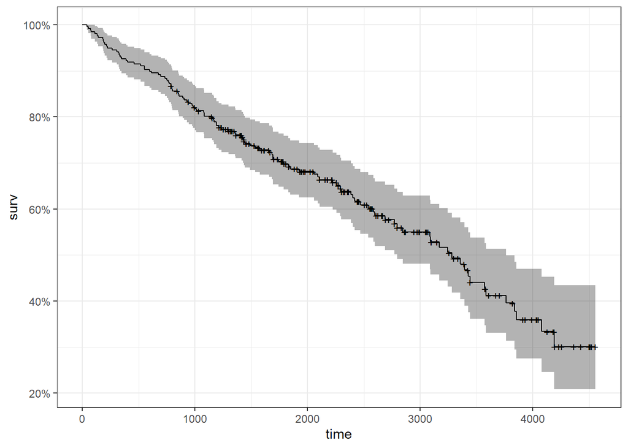

```r
#Generate the Kaplan-Meier survival curve and plot it with ggplot
#pull out time and status
t <- pbc[, "time"]
s <- pbc[, "status"]

km_fit <- survfit(Surv(t, s) ~ 1)

autoplot(km_fit) + theme_bw()
```

```r
#generate the probability of survival at certain times between registration and death
summary(km_fit, times = c(1:5, 50, 100, 150*(1:10), 300*(5:15)))
```

```
Call: survfit(formula = Surv(t, s) ~ 1)

 time n.risk n.event survival std.err lower 95% CI upper 95% CI
    1    258       0    1.000 0.00000        1.000        1.000
    2    258       0    1.000 0.00000        1.000        1.000
    3    258       0    1.000 0.00000        1.000        1.000
    4    258       0    1.000 0.00000        1.000        1.000
    5    258       0    1.000 0.00000        1.000        1.000
   50    257       1    0.996 0.00387        0.989        1.000
  100    254       1    0.984 0.00769        0.970        1.000
  150    251       1    0.973 0.01011        0.953        0.993
  300    244       1    0.946 0.01410        0.918        0.974
  450    237       1    0.919 0.01702        0.886        0.953
  600    232       1    0.899 0.01874        0.863        0.937
  750    228       1    0.880 0.02024        0.841        0.920
```

[output cut: 16 more lines]

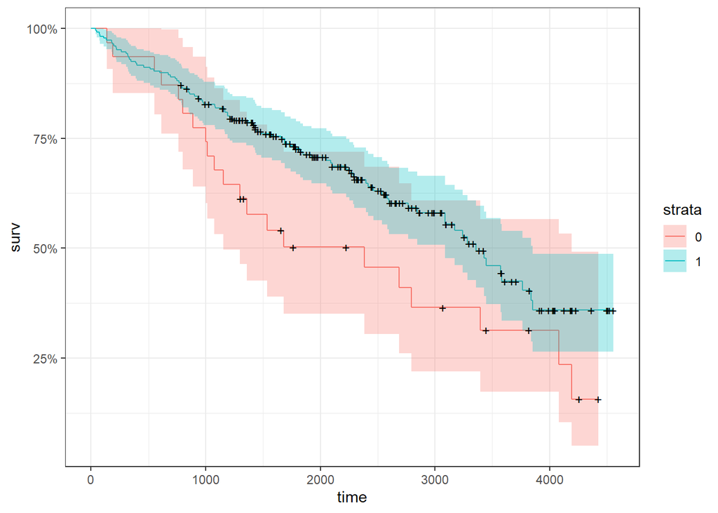

```r
#check km with sex
sex <- pbc[, "sex"]
km_sex <- survfit(Surv(t, s) ~ sex)

autoplot(km_sex) + theme_bw()
```

Can use the log-rank test from the survival test to compare the curves between the two groups.

Hypothesis test:

- $H_0$: in terms of survivability, there is no difference between the two groups
- $H_1$: there is a survival differential b/w the two groups

Use $\alpha = 0.05$ as the comparison for the p-value

```r
#log rank test to see the impact based on sex
survdiff(Surv(t, s) ~ sex)
```

```
Call:
survdiff(formula = Surv(t, s) ~ sex)

        N Observed Expected (O-E)^2/E (O-E)^2/V
sex=0  31       21     13.7     3.932      4.53
sex=1 227       90     97.3     0.552      4.53

 Chisq= 4.5  on 1 degrees of freedom, p= 0.03
```

p-value = $0.03 < \alpha$ so we reject the hull hypothesis as there is enough evidence of a survival difference b/w males and females.

```r
pbc %>% summarise(mean = mean(age))
```

```
      mean
1 50.42771
```

```r
#mean age = 50 so check for <= 50 (0) and > 50 (1)
pbc <- pbc %>% mutate(age2 = if_else(age > 50, 1, 0))

age <- pbc[, "age2"]

survdiff(Surv(t, s) ~ age)
```

```
Call:
survdiff(formula = Surv(t, s) ~ age)

        N Observed Expected (O-E)^2/E (O-E)^2/V
age=0 124       39       59      6.77      14.5
age=1 134       72       52      7.68      14.5

 Chisq= 14.5  on 1 degrees of freedom, p= 1e-04
```

p-value $< 0.005 < \alpha$ so we reject the null hypothesis as there is evidence of a difference in survival between those older than 50 and those younger than 50.

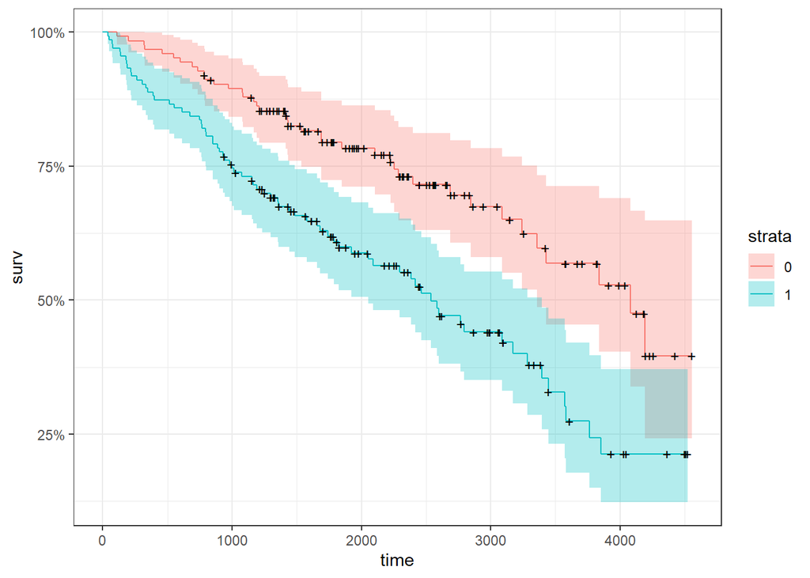

```r
#plot curve
km_age <- survfit(Surv(t, s) ~ age)
autoplot(km_age) + theme_bw()
```

```r
#check with treatment
trt <- pbc[, "trt"]
survdiff(Surv(t, s) ~ trt)
```

```
Call:
survdiff(formula = Surv(t, s) ~ trt)

        N Observed Expected (O-E)^2/E (O-E)^2/V
trt=1 127       57       54     0.171     0.333
trt=2 131       54       57     0.161     0.333

 Chisq= 0.3  on 1 degrees of freedom, p= 0.6
```

$p = 0.6 > \alpha$ so we fail to reject the null hypothesis as there is insufficient evidence of a difference in survivability b/w treatment groups.

#### Univariate Cox Models

(mostly for practice in understanding the models)

```r
#sex
coxph(Surv(time, status) ~ sex, data = pbc) %>%
  summary()
```

```
Call:
coxph(formula = Surv(time, status) ~ sex, data = pbc)

  n= 258, number of events= 111

       coef exp(coef) se(coef)      z Pr(>|z|)
sex -0.5133    0.5985   0.2439 -2.105   0.0353 *
---
Signif. codes:  0 '***' 0.001 '**' 0.01 '*' 0.05 '.' 0.1 ' ' 1

    exp(coef) exp(-coef) lower .95 upper .95
sex    0.5985      1.671    0.3711    0.9653

Concordance= 0.536  (se = 0.019 )
Likelihood ratio test= 3.98  on 1 df,   p=0.05
Wald test            = 4.43  on 1 df,   p=0.04
Score (logrank) test = 4.53  on 1 df,   p=0.03
```

log-rank matches the test from above with $p = 0.03$

```r
#age
coxph(Surv(time, status) ~ age, data = pbc) %>%
  summary()
```

```
Call:
coxph(formula = Surv(time, status) ~ age, data = pbc)

  n= 258, number of events= 111

        coef exp(coef) se(coef)     z Pr(>|z|)
age 0.041349  1.042216 0.009673 4.275 1.91e-05 ***
---
Signif. codes:  0 '***' 0.001 '**' 0.01 '*' 0.05 '.' 0.1 ' ' 1

    exp(coef) exp(-coef) lower .95 upper .95
age     1.042     0.9595     1.023     1.062

Concordance= 0.631  (se = 0.029 )
Likelihood ratio test= 18.23  on 1 df,   p=2e-05
Wald test            = 18.27  on 1 df,   p=2e-05
Score (logrank) test = 18.41  on 1 df,   p=2e-05
```

```r
#trt
coxph(Surv(time, status) ~ trt, data = pbc) %>%
  summary()
```

```
Call:
coxph(formula = Surv(time, status) ~ trt, data = pbc)

  n= 258, number of events= 111

       coef exp(coef) se(coef)      z Pr(>|z|)
trt -0.1099    0.8959   0.1902 -0.578    0.563

    exp(coef) exp(-coef) lower .95 upper .95
trt    0.8959      1.116    0.6172     1.301

Concordance= 0.507  (se = 0.026 )
Likelihood ratio test= 0.33  on 1 df,   p=0.6
Wald test            = 0.33  on 1 df,   p=0.6
Score (logrank) test = 0.33  on 1 df,   p=0.6
```

#### Multivariate Models

```r
m <- coxph(Surv(time, status) ~ age2 + sex + trt, data = pbc)

m %>% summary()
```

```
Call:
coxph(formula = Surv(time, status) ~ age2 + sex + trt, data = pbc)

  n= 258, number of events= 111

        coef exp(coef) se(coef)      z Pr(>|z|)
age2  0.7314    2.0781   0.2011  3.638 0.000275 ***
sex  -0.4840    0.6163   0.2431 -1.991 0.046483 *
trt  -0.0356    0.9650   0.1914 -0.186 0.852443
---
Signif. codes:  0 '***' 0.001 '**' 0.01 '*' 0.05 '.' 0.1 ' ' 1

     exp(coef) exp(-coef) lower .95 upper .95
age2    2.0781     0.4812    1.4013    3.0817
sex     0.6163     1.6225    0.3827    0.9925
trt     0.9650     1.0362    0.6632    1.4042

Concordance= 0.604  (se = 0.03 )
Likelihood ratio test= 18.24  on 3 df,   p=4e-04
Wald test            = 17.86  on 3 df,   p=5e-04
Score (logrank) test = 18.63  on 3 df,   p=3e-04
```

For all three tests (likelihood ratio, Wald, and logrank) $p < .005$ which is $< \alpha = 0.05$ so the overall model is significant and we reject the omnibus hypothesis (all $\beta$s are 0).

The HRs are:

- age: 2.0781
- sex: 0.6163
- trt: 0.9650

The HR for age and the lower p-value indicate a strong relationship b/w the patient’s age and increased risk of death. Specific wording: holding the other covariates constant, an increased age is associated with a poor survivall.

#### Testing Assumptions

```r
#proportional hazards
cox.zph(m)
```

```
       chisq df    p
age2   0.100  1 0.75
sex    0.234  1 0.63
trt    0.517  1 0.47
GLOBAL 0.864  3 0.83
```

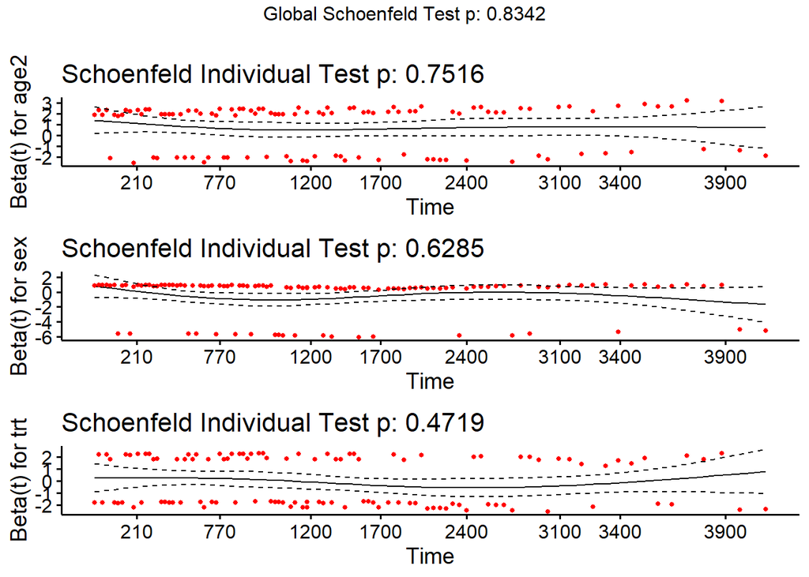

```r
ggcoxzph(cox.zph(m))
```

All p-values are $> \alpha$ so we do not have any coefficients with that are still time dependent.

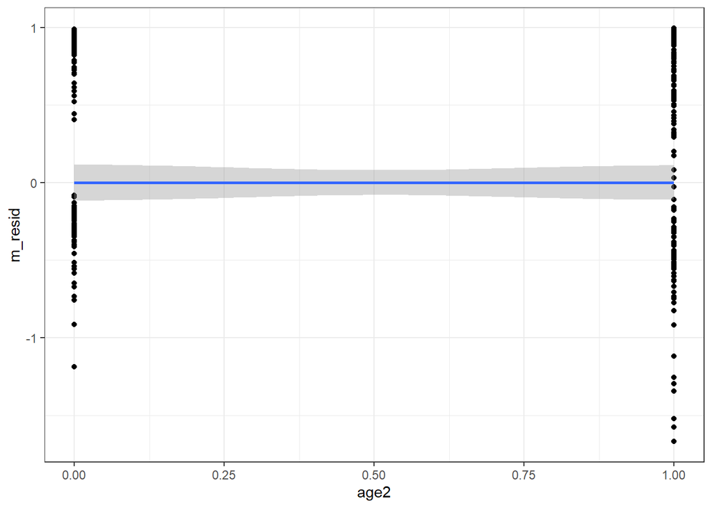

```r
#non-linearity
m_resid <- residuals(m, type = "martingale")

ggplot(data = pbc, mapping = aes(x = age2, y = m_resid)) +
  geom_point() +
  geom_smooth() +
  theme_bw()
```

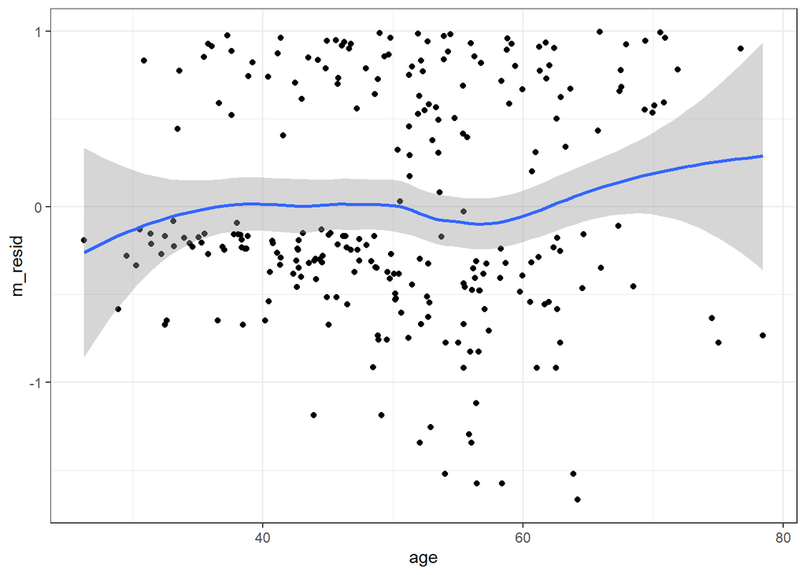

```r
#use the continuous age for comparison
ggplot(data = pbc, mapping = aes(x = age, y = m_resid)) +
  geom_point() +
  geom_smooth() +
  theme_bw()
```

The continuous version of age would be in violation, but the categorical one is not.